# Amruta Shelar Project-2

## Customer Churn Prediction

1. Business Problem:

Telecom companies want to identify customers who are likely to leave their services (churn). Predicting customer churn can help the company take appropriate retention actions.

2. Objective:

The objective is to build a Logistic Regression model that predicts whether a customer will churn or not based on their customer information and service details.

3. Target Variable:

Churn

- Yes → Customer will churn
- No → Customer will not churn
4. Independent Features:
- gender
- SeniorCitizen
- Partner
- Dependents
- tenure
- InternetService
- Contract
- PaymentMethod
- MonthlyCharges
- TotalCharges
- PhoneService

## Environment Setup and Data Loading

```python
# Import Libraries
import pandas as pd
import numpy as np

# Data Visualization
import matplotlib.pyplot as plt
import seaborn as sns

# Train Test Split
from sklearn.model_selection import train_test_split

# Data Preprocessing
from sklearn.preprocessing import StandardScaler, OneHotEncoder
from sklearn.compose import ColumnTransformer

# Logistic Regression Model
from sklearn.linear_model import LogisticRegression

# Load Dataset
df = pd.read_csv("Telco_Customer_Churn.csv")
df.head()
```

|  | gender | SeniorCitizen | Partner | Dependents | tenure | InternetService | Contract | PaymentMethod | MonthlyCharges | TotalCharges | PhoneService | Churn |
| --- | --- | --- | --- | --- | --- | --- | --- | --- | --- | --- | --- | --- |
| 0 | Female | 0 | Yes | No | 1 | DSL | Month-to-month | Electronic check | 29.85 | 29.85 | No | No |
| 1 | Male | 0 | No | No | 34 | DSL | One year | Mailed check | 56.95 | 1889.5 | Yes | No |
| 2 | Male | 0 | No | No | 2 | DSL | Month-to-month | Mailed check | 53.85 | 108.15 | Yes | Yes |
| 3 | Male | 0 | No | No | 45 | DSL | One year | Bank transfer (automatic) | 42.30 | 1840.75 | No | No |
| 4 | Female | 0 | No | No | 2 | Fiber optic | Month-to-month | Electronic check | 70.70 | 151.65 | Yes | Yes |

The dataset contains **7043 rows and 12 columns**.The `df.head()` displays the **first 5 rows** of the dataset.It is used to check whether the dataset is loaded correctly.

## Initial Data Profiling

```python
# Rows & Columns
df.shape
```

```
(7043, 12)
```

The dataset contains **7043 rows and 12 columns**.

```python
# Dataset Information
df.info()
```

```
<class 'pandas.DataFrame'>
RangeIndex: 7043 entries, 0 to 7042
Data columns (total 12 columns):
 #   Column           Non-Null Count  Dtype
---  ------           --------------  -----
 0   gender           7043 non-null   str
 1   SeniorCitizen    7043 non-null   int64
 2   Partner          7043 non-null   str
 3   Dependents       7043 non-null   str
 4   tenure           7043 non-null   int64
 5   InternetService  7043 non-null   str
 6   Contract         7043 non-null   str
 7   PaymentMethod    7043 non-null   str
 8   MonthlyCharges   7043 non-null   float64
 9   TotalCharges     7043 non-null   str
 10  PhoneService     7043 non-null   str
 11  Churn            7043 non-null   str
dtypes: float64(1), int64(2), str(9)
memory usage: 1.0 MB
```

The dataset contains **7043 rows and 12 columns**.

There are **9 categorical columns, 2 integer columns, and 1 float column**.

All columns contain **7043 non-null values**.

```python
# Summary Stastics
df.describe()
```

|  | SeniorCitizen | tenure | MonthlyCharges |
| --- | --- | --- | --- |
| count | 7043.000000 | 7043.000000 | 7043.000000 |
| mean | 0.162147 | 32.371149 | 64.761692 |
| std | 0.368612 | 24.559481 | 30.090047 |
| min | 0.000000 | 0.000000 | 18.250000 |
| 25% | 0.000000 | 9.000000 | 35.500000 |
| 50% | 0.000000 | 29.000000 | 70.350000 |
| 75% | 0.000000 | 55.000000 | 89.850000 |
| max | 1.000000 | 72.000000 | 118.750000 |

The dataset contains **7043 records**.

The average tenure is **32.37 months** and the average MonthlyCharges is **64.76**.

SeniorCitizen has a mean value of **0.16**, with values ranging from **0 to 1**.

The maximum tenure is **72 months**, and the maximum MonthlyCharges is **118.75**.

```python
# Missing Value
df.isnull().sum()
```

```
gender             0
SeniorCitizen      0
Partner            0
Dependents         0
tenure             0
InternetService    0
Contract           0
PaymentMethod      0
MonthlyCharges     0
TotalCharges       0
PhoneService       0
Churn              0
dtype: int64
```

All columns contain **0 missing values**. Therefore, the dataset does not have any missing values.

```python
# Duplicate Value
df.duplicated().sum()
```

```
np.int64(36)
```

The dataset contains **36 duplicate rows**. These duplicate rows need to be removed during data cleaning.

## Data Visualization

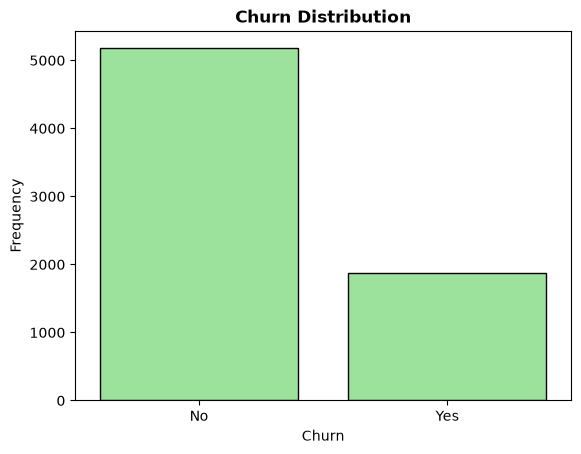

```python
# Count Plot
sns.countplot(x="Churn", data=df,edgecolor="black",color="lightgreen")

plt.title("Churn Distribution", fontweight="bold")
plt.xlabel("Churn")
plt.ylabel("Frequency")

plt.show()
```

The count plot shows the distribution of customers based on Churn.

Most customers have **Churn = No**, while fewer customers have **Churn = Yes**.

This shows that the number of customers who stayed is higher than the number of customers who churned.

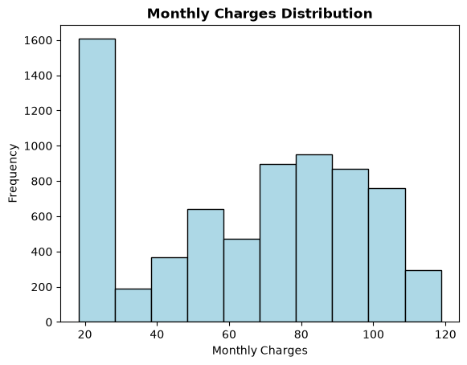

```python
# Histogram

plt.hist(df["MonthlyCharges"], edgecolor="black", color="lightblue")

plt.title("Monthly Charges Distribution", fontweight="bold")
plt.xlabel("Monthly Charges")
plt.ylabel("Frequency")

plt.show()
```

The histogram shows the distribution of Monthly Charges.

The values range approximately from **18 to 119**.

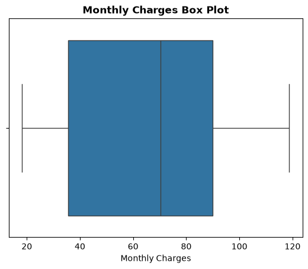

```python
# Box Plot
sns.boxplot(x=df["MonthlyCharges"])

plt.title("Monthly Charges Box Plot", fontweight="bold")
plt.xlabel("Monthly Charges")

plt.show()
```

The box plot shows the distribution of Monthly Charges.

The median Monthly Charge is approximately **70**.

The Monthly Charges range from approximately **18 to 118**.

No significant outliers are visible in the box plot.

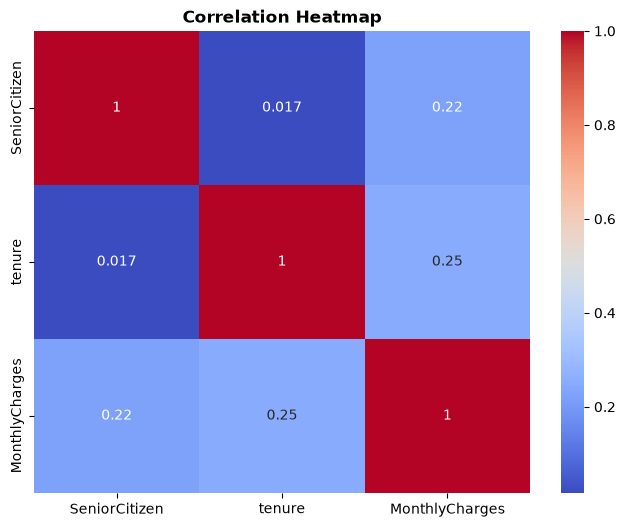

```python
# Correlation Heatmap
numeric_df = df.select_dtypes(include="number")

plt.figure(figsize=(8,6))

sns.heatmap(numeric_df.corr(),annot=True,cmap="coolwarm")

plt.title("Correlation Heatmap", fontweight="bold")

plt.show()
```

The heatmap shows the correlation between the numerical variables.

The correlation between **SeniorCitizen and tenure is 0.017**, which indicates a very weak relationship.

The correlation between **SeniorCitizen and MonthlyCharges is 0.22**, which indicates a weak positive relationship.

The correlation between **tenure and MonthlyCharges is 0.25**, which indicates a weak positive relationship.

## Data Cleaning

```python
df.drop_duplicates(inplace=True)
df.head()
```

|  | gender | SeniorCitizen | Partner | Dependents | tenure | InternetService | Contract | PaymentMethod | MonthlyCharges | TotalCharges | PhoneService | Churn |
| --- | --- | --- | --- | --- | --- | --- | --- | --- | --- | --- | --- | --- |
| 0 | Female | 0 | Yes | No | 1 | DSL | Month-to-month | Electronic check | 29.85 | 29.85 | No | No |
| 1 | Male | 0 | No | No | 34 | DSL | One year | Mailed check | 56.95 | 1889.5 | Yes | No |
| 2 | Male | 0 | No | No | 2 | DSL | Month-to-month | Mailed check | 53.85 | 108.15 | Yes | Yes |
| 3 | Male | 0 | No | No | 45 | DSL | One year | Bank transfer (automatic) | 42.30 | 1840.75 | No | No |
| 4 | Female | 0 | No | No | 2 | Fiber optic | Month-to-month | Electronic check | 70.70 | 151.65 | Yes | Yes |

There were **36 duplicate rows** in the dataset. The duplicate rows were removed using `drop_duplicates()`. After removing duplicates, the dataset contains **7007 rows**.

```python
df["TotalCharges"] = pd.to_numeric(df["TotalCharges"], errors="coerce")
df
```

|  | gender | SeniorCitizen | Partner | Dependents | tenure | InternetService | Contract | PaymentMethod | MonthlyCharges | TotalCharges | PhoneService | Churn |
| --- | --- | --- | --- | --- | --- | --- | --- | --- | --- | --- | --- | --- |
| 0 | Female | 0 | Yes | No | 1 | DSL | Month-to-month | Electronic check | 29.85 | 29.85 | No | No |
| 1 | Male | 0 | No | No | 34 | DSL | One year | Mailed check | 56.95 | 1889.50 | Yes | No |
| 2 | Male | 0 | No | No | 2 | DSL | Month-to-month | Mailed check | 53.85 | 108.15 | Yes | Yes |
| 3 | Male | 0 | No | No | 45 | DSL | One year | Bank transfer (automatic) | 42.30 | 1840.75 | No | No |
| 4 | Female | 0 | No | No | 2 | Fiber optic | Month-to-month | Electronic check | 70.70 | 151.65 | Yes | Yes |
| ... | ... | ... | ... | ... | ... | ... | ... | ... | ... | ... | ... | ... |
| 7038 | Male | 0 | Yes | Yes | 24 | DSL | One year | Mailed check | 84.80 | 1990.50 | Yes | No |
| 7039 | Female | 0 | Yes | Yes | 72 | Fiber optic | One year | Credit card (automatic) | 103.20 | 7362.90 | Yes | No |
| 7040 | Female | 0 | Yes | Yes | 11 | DSL | Month-to-month | Electronic check | 29.60 | 346.45 | No | No |
| 7041 | Male | 1 | Yes | No | 4 | Fiber optic | Month-to-month | Mailed check | 74.40 | 306.60 | Yes | Yes |
| 7042 | Male | 0 | No | No | 66 | Fiber optic | Two year | Bank transfer (automatic) | 105.65 | 6844.50 | Yes | No |

7007 rows × 12 columns

## Data Preprocessing

```python
# Numerical Columns
numeric_features = ["SeniorCitizen","tenure","MonthlyCharges","TotalCharges"]

# Categorical Columns
categorical_features = ["gender","Partner","Dependents","InternetService","Contract","PaymentMethod","PhoneService"]
```

The dataset contains **4 numerical features** and **7 categorical features**. Numerical features are selected for **scaling**, while categorical features are selected for **One-Hot Encoding**.

```python
X_num = df[numeric_features]
X_cat = df[categorical_features]
```

The numerical and categorical features were separated into two groups. `X_num` contains the **numerical features**, while `X_cat` contains the **categorical features**.

```python
# Handle Missing Value
from sklearn.impute import SimpleImputer

imputer = SimpleImputer(strategy="median")

X_num = pd.DataFrame(
    imputer.fit_transform(X_num),
    columns=numeric_features
)
```

The missing values in numerical columns were filled using the **median value**. After imputation, the numerical data was ready for further preprocessing.

```python
# Feature Scaling
scaler = StandardScaler()

X_num_scaled = pd.DataFrame(
    scaler.fit_transform(X_num),
    columns=numeric_features
)
```

The numerical features were scaled using **StandardScaler**. This brings the numerical features to a **common scale** for better model performance.

```python
# OneHotEncoder
encoder = OneHotEncoder(sparse_output=False,handle_unknown="ignore")

X_cat_encoded = encoder.fit_transform(X_cat)

encoded_columns = encoder.get_feature_names_out(categorical_features)

X_cat_encoded = pd.DataFrame(
    X_cat_encoded,
    columns=encoded_columns
)
```

The categorical features were converted into **numerical format** using OneHotEncoder. The categorical columns were converted into **separate binary columns** for model training.

```python
# Target Variable
y = df["Churn"].map({"Yes": 1, "No": 0})
y
```

```
0       0
1       0
2       1
3       0
4       1
       ..
7038    0
7039    0
7040    0
7041    1
7042    0
Name: Churn, Length: 7007, dtype: int64
```

```python
# Combine All Features
X_final = pd.concat(
    [X_num_scaled, X_cat_encoded],
    axis=1
)
X_final
```

|  | SeniorCitizen | tenure | MonthlyCharges | TotalCharges | gender_Female | gender_Male | Partner_No | Partner_Yes | Dependents_No | Dependents_Yes | ... | InternetService_No | Contract_Month-to-month | Contract_One year | Contract_Two year | PaymentMethod_Bank transfer (automatic) | PaymentMethod_Credit card (automatic) | PaymentMethod_Electronic check | PaymentMethod_Mailed check | PhoneService_No | PhoneService_Yes |
| --- | --- | --- | --- | --- | --- | --- | --- | --- | --- | --- | --- | --- | --- | --- | --- | --- | --- | --- | --- | --- | --- |
| 0 | -0.441034 | -1.286125 | -1.167666 | -0.999336 | 1.0 | 0.0 | 0.0 | 1.0 | 1.0 | 0.0 | ... | 0.0 | 1.0 | 0.0 | 0.0 | 0.0 | 0.0 | 1.0 | 0.0 | 1.0 | 0.0 |
| 1 | -0.441034 | 0.059863 | -0.265603 | -0.178353 | 0.0 | 1.0 | 1.0 | 0.0 | 1.0 | 0.0 | ... | 0.0 | 0.0 | 1.0 | 0.0 | 0.0 | 0.0 | 0.0 | 1.0 | 0.0 | 1.0 |
| 2 | -0.441034 | -1.245337 | -0.368791 | -0.964769 | 0.0 | 1.0 | 1.0 | 0.0 | 1.0 | 0.0 | ... | 0.0 | 1.0 | 0.0 | 0.0 | 0.0 | 0.0 | 0.0 | 1.0 | 0.0 | 1.0 |
| 3 | -0.441034 | 0.508525 | -0.753250 | -0.199875 | 0.0 | 1.0 | 1.0 | 0.0 | 1.0 | 0.0 | ... | 0.0 | 0.0 | 1.0 | 0.0 | 1.0 | 0.0 | 0.0 | 0.0 | 1.0 | 0.0 |
| 4 | -0.441034 | -1.245337 | 0.192085 | -0.945565 | 1.0 | 0.0 | 1.0 | 0.0 | 1.0 | 0.0 | ... | 0.0 | 1.0 | 0.0 | 0.0 | 0.0 | 0.0 | 1.0 | 0.0 | 0.0 | 1.0 |
| ... | ... | ... | ... | ... | ... | ... | ... | ... | ... | ... | ... | ... | ... | ... | ... | ... | ... | ... | ... | ... | ... |
| 7002 | -0.441034 | -0.348012 | 0.661424 | -0.133764 | 0.0 | 1.0 | 0.0 | 1.0 | 0.0 | 1.0 | ... | 0.0 | 0.0 | 1.0 | 0.0 | 0.0 | 0.0 | 0.0 | 1.0 | 0.0 | 1.0 |
| 7003 | -0.441034 | 1.609788 | 1.273894 | 2.237999 | 1.0 | 0.0 | 0.0 | 1.0 | 0.0 | 1.0 | ... | 0.0 | 0.0 | 1.0 | 0.0 | 0.0 | 1.0 | 0.0 | 0.0 | 0.0 | 1.0 |
| 7004 | -0.441034 | -0.878250 | -1.175987 | -0.859566 | 1.0 | 0.0 | 0.0 | 1.0 | 0.0 | 1.0 | ... | 0.0 | 1.0 | 0.0 | 0.0 | 0.0 | 0.0 | 1.0 | 0.0 | 1.0 | 0.0 |
| 7005 | 2.267400 | -1.163762 | 0.315245 | -0.877159 | 0.0 | 1.0 | 0.0 | 1.0 | 1.0 | 0.0 | ... | 0.0 | 1.0 | 0.0 | 0.0 | 0.0 | 0.0 | 0.0 | 1.0 | 0.0 | 1.0 |
| 7006 | -0.441034 | 1.365063 | 1.355446 | 2.009140 | 0.0 | 1.0 | 1.0 | 0.0 | 1.0 | 0.0 | ... | 0.0 | 0.0 | 0.0 | 1.0 | 1.0 | 0.0 | 0.0 | 0.0 | 0.0 | 1.0 |

7007 rows × 22 columns

The scaled numerical features and encoded categorical features were combined into a single dataset. The final feature dataset `X_final` is ready for **model training**.

```python
# Train Test Split
X_train, X_test, y_train, y_test = train_test_split(
    X_final,
    y,
    test_size=0.2,
    random_state=42
)

print(f"Training data shape: X={X_train.shape}, y={y_train.shape}")
print(f"Testing data shape: X={X_test.shape}, y={y_test.shape}")
```

```
Training data shape: X=(5605, 22), y=(5605,)
Testing data shape: X=(1402, 22), y=(1402,)
```

The dataset was divided into **80% training data** and **20% testing data**. The training data is used to **train the Logistic Regression model**, while the testing data is used to **evaluate the model**. `random_state=42` ensures the same split is obtained every time.

## Model Training

```python
# Model Training
model = LogisticRegression()

model.fit(X_train, y_train)
```

```
LogisticRegression()
```

The Logistic Regression model was created and trained using the **training data**. The model learns the relationship between the customer features and **Churn (0/1)**.

```python
print(model.coef_)
print(model.intercept_)
```

```
[[ 0.10594561 -1.32932437  0.2139606   0.59232691 -0.22502058 -0.24075159
  -0.24073268 -0.22503949 -0.13977579 -0.32599638 -0.26968388  0.5213241
  -0.71741239  0.71502487 -0.15478563 -1.02601141 -0.09800151 -0.25427986
   0.2129682  -0.32645899  0.10918667 -0.57495884]]
[-0.56604025]
```

The model coefficients show the effect of each feature on the predicted Churn. The model has 22 coefficients, one for each feature. The intercept value is -0.566.

## Model Prediction & Evaluation

```python
y_pred = model.predict(X_test)
```

The trained Logistic Regression model was used to predict the **Churn values for the test data**. The predicted values are stored in `y_pred`.

```python
from sklearn.metrics import ( accuracy_score, precision_score, recall_score, f1_score, roc_auc_score)

# Accuracy
accuracy = accuracy_score(y_test, y_pred)

# Precision
precision = precision_score(y_test, y_pred)

# Recall
recall = recall_score(y_test, y_pred)

# F1 Score
f1 = f1_score(y_test, y_pred)

# ROC-AUC
y_prob = model.predict_proba(X_test)[:, 1]
roc_auc = roc_auc_score(y_test, y_prob)

print("--- Logistic Regression Evaluation Metrics ---")
print(f"Accuracy:  {accuracy:.4f} ({accuracy*100:.2f}%)")
print(f"Precision: {precision:.4f}")
print(f"Recall:    {recall:.4f}")
print(f"F1 Score:  {f1:.4f}")
print(f"ROC-AUC:   {roc_auc:.4f}")
```

```
--- Logistic Regression Evaluation Metrics ---
Accuracy:  0.7953 (79.53%)
Precision: 0.6161
Recall:    0.5320
F1 Score:  0.5710
ROC-AUC:   0.8383
```

The Logistic Regression model achieved an **Accuracy of 79.53%**.

The **Precision is 0.6161**, which shows the accuracy of positive Churn predictions.

The **Recall is 0.5320**, which shows the model identified about 53.20% of actual Churn cases.

The **F1 Score is 0.5710**, which represents the balance between Precision and Recall.

The **ROC-AUC score is 0.8383**, indicating good performance in distinguishing between Churn and No Churn customers.

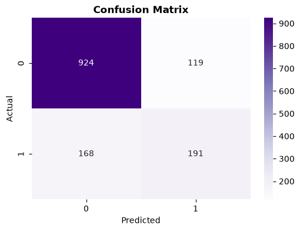

```python
# Confusion matrix
from sklearn.metrics import confusion_matrix

cm = confusion_matrix(y_test, y_pred)

plt.figure(figsize=(6, 4))
sns.heatmap(cm, annot=True, fmt="d", cmap="Purples")
plt.title("Confusion Matrix", fontweight="bold")
plt.xlabel("Predicted")
plt.ylabel("Actual")
plt.show()
```

The confusion matrix shows the actual and predicted Churn values on the test data.

The model correctly predicted **924 No-Churn** and **191 Churn** cases.

It incorrectly predicted **119 No-Churn** and **168 Churn** cases.

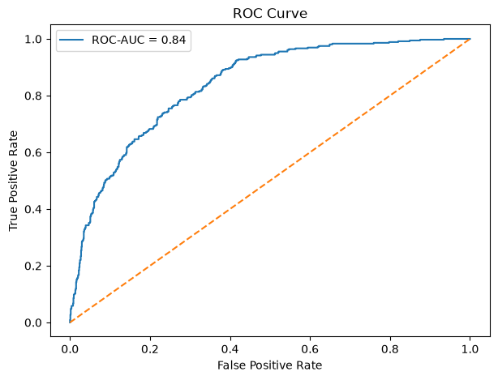

```python
from sklearn.metrics import roc_curve, roc_auc_score

# Predicted probabilities for Class 1
y_prob = model.predict_proba(X_test)[:, 1]

# Calculate False Positive Rate and True Positive Rate
fpr, tpr, thresholds = roc_curve(y_test, y_prob)

# Calculate ROC-AUC
roc_auc = roc_auc_score(y_test, y_prob)

# Plot ROC Curve
plt.figure(figsize=(7, 5))
plt.plot(fpr, tpr, label=f"ROC-AUC = {roc_auc:.2f}")
plt.plot([0, 1], [0, 1], linestyle="--")

plt.xlabel("False Positive Rate")
plt.ylabel("True Positive Rate")
plt.title("ROC Curve")
plt.legend()
plt.show()
```

The ROC Curve shows the performance of the Logistic Regression model in distinguishing between Churn and No Churn customers.

The model achieved a **ROC-AUC score of 0.84**, which indicates good classification performance.

# Model Interpretation & Business Insights

```python
coefficients = model.coef_[0]

feature_names = X_final.columns

coef_df = pd.DataFrame({
    "Feature": feature_names,
    "Coefficient": coefficients
})

coef_df.sort_values(
    by="Coefficient",
    ascending=False
)
```

|  | Feature | Coefficient |
| --- | --- | --- |
| 13 | Contract_Month-to-month | 0.715025 |
| 3 | TotalCharges | 0.592327 |
| 11 | InternetService_Fiber optic | 0.521324 |
| 2 | MonthlyCharges | 0.213961 |
| 18 | PaymentMethod_Electronic check | 0.212968 |
| 20 | PhoneService_No | 0.109187 |
| 0 | SeniorCitizen | 0.105946 |
| 16 | PaymentMethod_Bank transfer (automatic) | -0.098002 |
| 8 | Dependents_No | -0.139776 |
| 14 | Contract_One year | -0.154786 |
| 4 | gender_Female | -0.225021 |
| 7 | Partner_Yes | -0.225039 |
| 6 | Partner_No | -0.240733 |
| 5 | gender_Male | -0.240752 |
| 17 | PaymentMethod_Credit card (automatic) | -0.254280 |
| 10 | InternetService_DSL | -0.269684 |
| 9 | Dependents_Yes | -0.325996 |
| 19 | PaymentMethod_Mailed check | -0.326459 |
| 21 | PhoneService_Yes | -0.574959 |
| 12 | InternetService_No | -0.717412 |
| 15 | Contract_Two year | -1.026011 |
| 1 | tenure | -1.329324 |

The coefficients show how different features influence customer churn.

Features with **positive coefficients** have a higher tendency towards churn, while features with **negative coefficients** have a lower tendency towards churn.

The highest positive coefficient is for **Contract_Month-to-month (0.715)**.

The highest negative coefficient is for **tenure (-1.329)**.

### Business Insights

- Month-to-month contract customers have a higher likelihood of churn.
- Customers with longer tenure are less likely to churn.
- Two-year contract customers have a lower likelihood of churn.
- Fiber optic internet service is positively associated with churn. -Electronic check payment method shows a positive relationship with churn.
- Customers with no internet service show a lower likelihood of churn.
- Contract type and customer tenure are important factors related to customer churn.

## Conclusion & Future Scope

## Conclusion

The IBM Telco Customer Churn dataset was analyzed using Exploratory Data Analysis, Data Cleaning, and Data Preprocessing.

A Logistic Regression model was trained to predict whether a customer is likely to churn or not.

The model was evaluated using Accuracy, Precision, Recall, F1-score, and ROC-AUC.

The analysis showed that factors such as customer tenure, contract type, internet service, and payment method have important relationships with customer churn.

## Future Scope

- Improve model performance using hyperparameter tuning.
- Compare Logistic Regression with other classification algorithms such as Decision Tree and Random Forest.
- Use additional customer data to improve churn prediction.
- Develop a system that identifies high-risk customers automatically.
- Use the predictions to design effective customer retention strategies.